# Airlines Analysis

Robert Dunne

10/18/2021

# Airport Analysis

The US flight data for 2015 contains over 200,000 records of inter-state flights. We have been asked to explore this data, find insights and discuss them. To begin, we took a look at our datasets to see what we are dealing with. Not all of them are included here but we will take a **glimpse** at the biggest one. The US records has over 200,000 rows of flight details and the one we will be dealing with mostly.

```r
glimpse(us_records)
```

```
## Rows: 231,603
## Columns: 31
## $ YEAR                <dbl> 2015, 2015, 2015, 2015, 2015, 2015, 2015, 2015, 20…
## $ MONTH               <dbl> 7, 7, 7, 7, 7, 7, 7, 7, 7, 7, 7, 7, 7, 7, 7, 7, 7,…
## $ DAY                 <dbl> 1, 1, 1, 1, 1, 1, 1, 1, 1, 1, 1, 1, 1, 1, 1, 1, 1,…
## $ DAY_OF_WEEK         <dbl> 3, 3, 3, 3, 3, 3, 3, 3, 3, 3, 3, 3, 3, 3, 3, 3, 3,…
## $ AIRLINE             <chr> "NK", "AA", "DL", "NK", "UA", "AA", "AA", "AA", "U…
## $ FLIGHT_NUMBER       <dbl> 298, 1965, 2020, 612, 1044, 260, 448, 2406, 1928, …
## $ TAIL_NUMBER         <chr> "N624NK", "N507AY", "N3759", "N629NK", "N39418", "…
## $ ORIGIN_AIRPORT      <chr> "LAS", "SFO", "LAX", "LAS", "ANC", "LAX", "SLC", "…
## $ DESTINATION_AIRPORT <chr> "IAH", "CLT", "MEM", "MSP", "ORD", "MIA", "CLT", "…
## $ SCHEDULED_DEPARTURE <dbl> 3, 5, 5, 5, 8, 10, 15, 15, 22, 24, 25, 25, 25, 25,…
## $ DEPARTURE_TIME      <dbl> 41, 2400, 2400, 53, 17, 5, 22, 35, 43, 17, 23, 36,…
## $ DEPARTURE_DELAY     <dbl> 38, -5, -5, 48, 9, -5, 7, 20, 21, -7, -2, 11, -7, …
## $ TAXI_OUT            <dbl> 11, 21, 36, 14, 20, 33, 13, 28, 15, 9, 12, 11, 14,…
```

[output cut: 18 more lines]

I don’t typically like to alter loaded datasets during data exploration because things can get very messy if you make a mistake or happen to group the wrong variable or delete a column by mistake. That’s why I create new dataframes based off the criteria I need and give them intuitive names in the process.

## Exploring our data

The first thing we do is take a look at our data, its dimensions and see where we think there might be areas or interest we can explore further. One of the biggest issues is that I am unfamiliar with the terminology of the datasets and this provided a stumbling block. It is more time-consuming when you have to familiarise yourself with the data first.

During this period, I discovered a lot about the data and a lot of my assumptions about the data were questioned. For example, several flight numbers are the same but they are, in fact, different routes so grouping by flight number is pointless. Therefore, I have to find a way to find unique combinations of routes.

### Busiest Routes

I did this using dplyr. Here are the steps I took to get them.

- Select the two columns I was interested in - origin airport and destination airport.
- Grouped by those two columns and then use **tally()** to get the number of times they occur.
- Joined the US Airports to get the name of the airports based off their IATA Code.
- Arranged the dataset by how many flights there were.
- There were 601 flights between San Francisco and Los Angeles in 2015.

Then I plotted the data using *geom_polgon* and also *geom_edges*.

[figure not shown]

```r
# We can also see this when we mutate the dataframe and group by Airline and Flight Number. We will have
# to find another way to find unique routes and how often there are flights between those two
# airports

unique_routes <- us_records %>% select(ORIGIN_AIRPORT, DESTINATION_AIRPORT)

unique_routes1 <- unique_routes %>% group_by(ORIGIN_AIRPORT, DESTINATION_AIRPORT) %>% tally()

busiest_routes1 <- left_join(unique_routes1, us_airports, by = c("ORIGIN_AIRPORT" = "IATA_CODE"))
busiest_routes2 <- left_join(busiest_routes1, us_airports, by = c("DESTINATION_AIRPORT" = "IATA_CODE"))

busiest_routes2 <- busiest_routes2 %>%
  arrange(desc(n)) %>%
  head(5)

ggplot() +
  geom_polygon(data = us, aes(x=long, y = lat, group = group, fill='red'), fill='#e5e5e5') +
  geom_text(data = busiest_routes2, aes(LONGITUDE.y, LATITUDE.y, label=CITY.y),
            size = 3.5, nudge_y = -1, nudge_x = -1, color='black') +
  geom_point(data = busiest_routes2, aes(x = LONGITUDE.y, y = LATITUDE.y),
             color='blue', alpha=0.6) +
  geom_point(data = busiest_routes2, aes(x = LONGITUDE.x, y = LATITUDE.x),
             color='#f07167', alpha=0.6) +
  geom_edges(data = busiest_routes2, mapping = aes(x = LONGITUDE.x, y = LATITUDE.x, xend = LONGITUDE.y, yend = LATITUDE.y),
             color = "black", curvature = 0.3, arrow = arrow(length = unit(0.3, "lines"), type = "closed")) +
  coord_fixed(1.3) +
  theme_void() +
  plot_annotation(
    title = "10 busiest routes in the US in 2015",
    subtitle = "Flights between the cities are one-way")
```

### Weather Delay

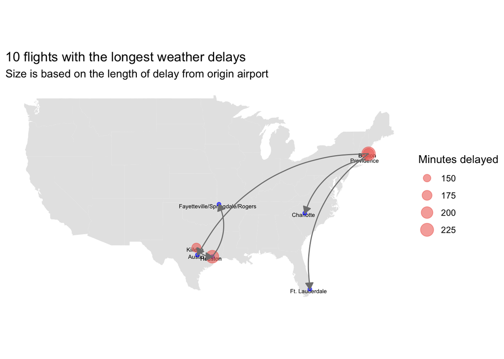

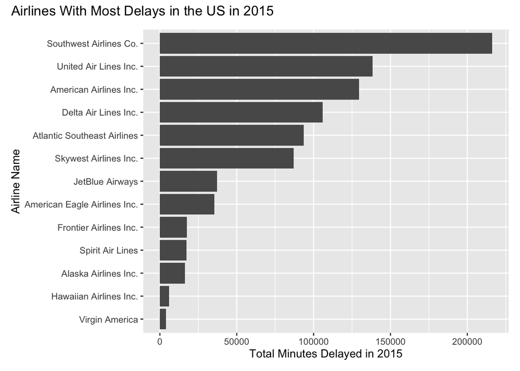

```r
airline_delays <- us_records %>%
  group_by(AIRLINE) %>%
  summarise(
    minutes_delayed = sum(AIRLINE_DELAY, na.rm=T)
  ) %>%
  arrange(desc(minutes_delayed))

# joined the two dataframes so we have the airport name and not just a code for it

airline_delays1 <- left_join(airline_delays, us_airlines, by = c("AIRLINE" = "IATA_CODE"))

lines_colour <- 'black'
bg_colour <- 'white'

ggplot(airline_delays1, aes(minutes_delayed, reorder(AIRLINE.y, minutes_delayed))) +
  geom_bar(stat='identity') +
  labs(x = 'Total Minutes Delayed in 2015',
       y = 'Airline Name') +
  plot_annotation(
    title = "Airlines With Most Delays in the US in 2015")
```

### Busiest Airports

Next, I decided to have a look at the airport that serves the most cities.

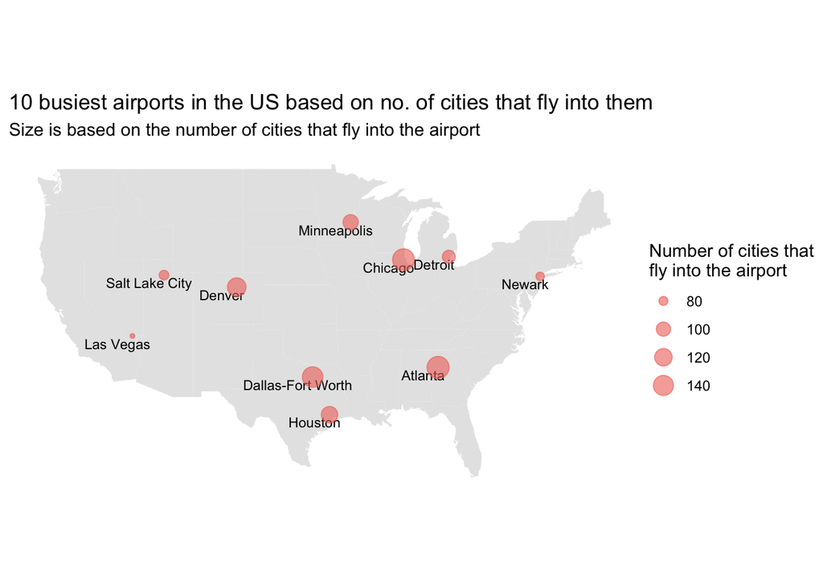

```r
top_distance_dep <- us_records %>%
  group_by(ORIGIN_AIRPORT) %>%
  summarise(
    arrival_count = n_distinct(DESTINATION_AIRPORT),
    grand_total_distance = sum(DISTANCE, na.rm = T),
    average_delay = mean(DEPARTURE_DELAY, na.rm=T)
  ) %>%
  arrange(desc(arrival_count)) %>%
  head(10)

top_distance_dest <- us_records %>%
  group_by(DESTINATION_AIRPORT) %>%
  summarise(
    arrival_count = n_distinct(ORIGIN_AIRPORT),
    grand_total_distance = sum(DISTANCE, na.rm = T),
    average_delay = mean(ARRIVAL_DELAY, na.rm=T)
  ) %>%
  arrange(desc(arrival_count)) %>%
  head(10)

top_distance_dep1 <- left_join(top_distance_dep, us_airports, by = c("ORIGIN_AIRPORT" = "IATA_CODE"))
top_distance_dest1 <- left_join(top_distance_dest, us_airports, by = c("DESTINATION_AIRPORT" = "IATA_CODE"))

ggplot() +
  geom_polygon(data = us, aes(x=long, y = lat, group = group, fill='red'), fill='#e5e5e5') +
  geom_text(data = top_distance_dest1, aes(LONGITUDE, LATITUDE, label = CITY),
            size = 3, nudge_y = -0.6, nudge_x = -1.5, color='black') +
  geom_point(data = top_distance_dest1, aes(x = LONGITUDE, y = LATITUDE, size = arrival_count),
             color='#f07167', alpha=0.6) +
  coord_fixed(1.3) +
  labs(size = "Number of cities that\nfly into the airport") +
  theme_void() +
  scale_fill_viridis_d()  +
  plot_annotation(
    title = "10 busiest airports in the US based on no. of cities that fly into them",
    subtitle = "Size is based on the number of cities that fly into the airport")
```

### Airline Delays Table

I decided to have a go at creating a gt Table using the *gt* package by [Thomas Mock](https://themockup.blog/) and also a newer addition to his wide array of libraries *gtExtras*

After looking at the delays, I wanted to take a closer look at the airlines in an effort to explain why Southwest Airlines had so many many delays. The answer is clear in that they flew the most and their average delay actually drops to just over 15 when you consider how often they fly.

```r
top_airlines <- us_records %>%
  group_by(AIRLINE) %>%
  summarise(
    arrival_count = n(),
    grand_total_distance = sum(DISTANCE, na.rm = T),
    average_delay = mean(DEPARTURE_DELAY, na.rm=T)
  ) %>%
  arrange(desc(arrival_count)) %>%
  head(10)

top_airlines1 <- left_join(top_airlines, us_airlines, by = c("AIRLINE" = "IATA_CODE"))


top_airlines1 %>%
  select(arrival_count, grand_total_distance, average_delay, AIRLINE.y) %>%
  gt() %>%
  cols_move_to_start(columns = AIRLINE.y) %>%
  cols_label(
    AIRLINE.y = "Airline Name",
    arrival_count = "Number Of Flights",
    grand_total_distance = "Number of Air Miles",
    average_delay = "Average Delay"
  ) %>%
fmt_number(
  columns = c(average_delay),
  decimals = 2
) %>%
  fmt_number(
    columns = c(arrival_count, grand_total_distance),
    decimals = 0
  ) %>%
  gt_theme_538() %>%
  tab_source_note("Table by: Robert Dunne") %>%
  tab_header(title = md("**The Top Airlines in the US in 2015**"),
             subtitle = "All US flights") %>%
  gt_color_rows(arrival_count:average_delay, palette = "ggsci::blue_material") %>%
  tab_style(
    style = list(
      cell_borders(
        sides = "bottom",
        color = "black",
        weight = px(3)
      )
    ),
    locations = list(
      cells_column_labels(
        columns = gt::everything()
      )
    )
  )
```

**The Top Airlines in the US in 2015**

All US flights

| Airline Name | Number Of Flights | Number of Air Miles | Average Delay |
| --- | --- | --- | --- |
| Southwest Airlines Co. | 50,688 | 38,720,438 | 15.58 |
| American Airlines Inc. | 36,367 | 38,004,261 | 8.74 |
| Delta Air Lines Inc. | 35,598 | 31,102,950 | 8.12 |
| Skywest Airlines Inc. | 23,234 | 11,728,463 | 10.05 |
| Atlantic Southeast Airlines | 22,224 | 10,238,779 | 10.44 |
| United Air Lines Inc. | 20,538 | 26,994,537 | 22.61 |
| American Eagle Airlines Inc. | 11,126 | 4,749,540 | 10.37 |
| JetBlue Airways | 10,845 | 11,662,867 | 9.88 |
| Alaska Airlines Inc. | 7,136 | 8,467,842 | 2.12 |
| Spirit Air Lines | 4,657 | 4,509,447 | 14.98 |

Table by: Robert Dunne

We now move on to try and predict the air time based on the distance between the two airports in questions. For this, we will need the *AIR_TIME* and *DISTANCE* variables from the **us-records** dataset we loaded earlier.

I used tidymodels for this and after splitting my data into training and sets, I declared the model as being linear_regression. I cleaned up some of the data to remove flights that had 0 minutes flying time and after that, I got, as you can see, a 99% correlation between the two variables.

```r
distance_air <- us_records %>%
  filter(CANCELLED == 0, AIR_TIME > 0) %>%
  select(DISTANCE, AIR_TIME, CANCELLED)

distance_air[is.na(distance_air)] <- 0

cor(distance_air$AIR_TIME, distance_air$DISTANCE)
```

```
## [1] 0.9914567
```

We can visualise the correlation too.

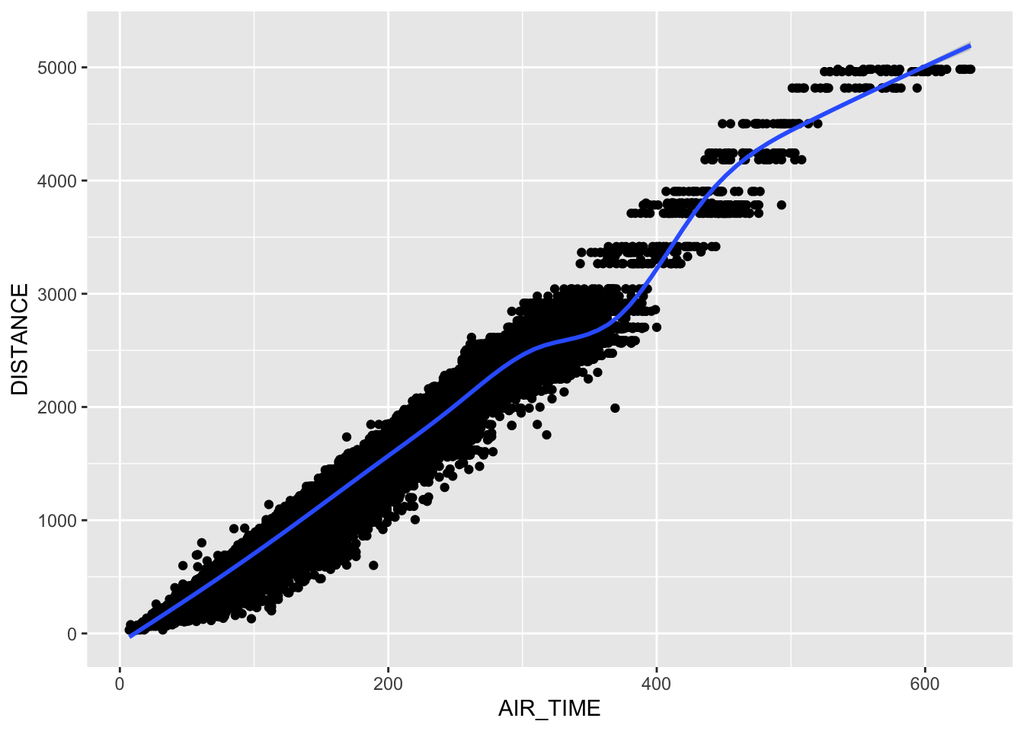

```r
ggplot(distance_air, aes(AIR_TIME, DISTANCE)) +
  geom_point() +
  geom_smooth()
```

```r
set.seed(314)

air_distance <- us_records %>% select(AIR_TIME, DISTANCE)

#split data in two groups
air_distance_split <- initial_split(air_distance, prop=0.75,
                                    strate = AIR_TIME)

# Create a split object
air_distance_train <- air_distance_split %>% training()

# Build training data set
air_distance_test <- air_distance_split %>% testing()

# specifying our model

lm_model <- linear_reg() %>%
  set_engine('lm') %>%
  set_mode('regression')

lm_model
```

```
## Linear Regression Model Specification (regression)
##
## Computational engine: lm
```

```r
lm_fit <- lm_model %>%
  fit(AIR_TIME ~ ., data = air_distance_train)
```

```r
summary(lm_fit$fit)
```

```
##
## Call:
## stats::lm(formula = AIR_TIME ~ ., data = data)
##
## Residuals:
##     Min      1Q  Median      3Q     Max
## -90.157  -5.158  -1.076   4.134 121.131
##
## Coefficients:
##              Estimate Std. Error t value Pr(>|t|)
## (Intercept) 1.711e+01  3.866e-02   442.6   <2e-16 ***
## DISTANCE    1.160e-01  3.679e-05  3151.8   <2e-16 ***
## ---
## Signif. codes:  0 '***' 0.001 '**' 0.01 '*' 0.05 '.' 0.1 ' ' 1
##
## Residual standard error: 9.515 on 171363 degrees of freedom
##   (2337 observations deleted due to missingness)
## Multiple R-squared:  0.983,  Adjusted R-squared:  0.983
## F-statistic: 9.934e+06 on 1 and 171363 DF,  p-value: < 2.2e-16
```

We add the predicted value into our dataset and take a look at how well it performs. We can see that the p-value is very, very small which means the correlation is significant.

```r
air_distance_test_results <- predict(lm_fit, new_data = air_distance_test) %>%
  bind_cols(air_distance_test)

air_distance_test_results
```

```
## # A tibble: 57,901 × 3
##    .pred AIR_TIME DISTANCE
##    <dbl>    <dbl>    <dbl>
##  1  289.      292     2342
##  2  160.      163     1235
##  3  210.      194     1660
##  4  269.      255     2176
##  5  201.      185     1589
##  6  159.      155     1222
##  7  193.      184     1514
##  8  204.      194     1609
##  9  293.      267     2378
## 10  185.      180     1448
## # … with 57,891 more rows
```

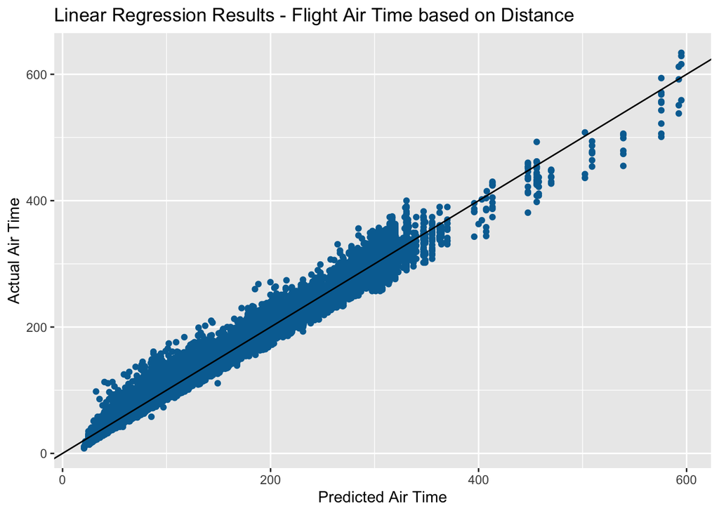

```r
ggplot(data = air_distance_test_results,
       mapping = aes(x = .pred, y = AIR_TIME)) +
  geom_point(color = '#006EA1') +
  geom_abline(intercept = 0, slope = 1, color = 'black') +
  labs(title = 'Linear Regression Results - Flight Air Time based on Distance',
       x = 'Predicted Air Time',
       y = 'Actual Air Time')
```

## Reflection

This was quite the undertaking given the large sums of data and while that made the possibilities endless, that isn’t always necessarily a good thing. I learned a lot about the various libraries you can use to help you manipulate data. R’s dplyr is very powerful and I found that once I found the right way to ask a question, the solution could be found online.

### Improving processes

I can only imagine that in a professional setting, you will be asked to do this kind of thing regularly and that would give me a chance to improve my processes for how to explore the data and how to manipulate it. I would also hope to be working with data I am familiar with to make the learning curve a little less steep. Having said that, it was a good chance to dive into a dataset and have to figure out how to manipulate the data.

### Data visualisation

I would like to improve on my data visualizations. I learned very quickly that the scope for what you can do in R is incredible and there seems to be a solution for anything you want to create. Obviously, it depends on the goal of the analysis in a professional setting. Is my goal predicting an outcome or presenting to an audience? Depending on the context, I would pour more time into whatever aspect I felt needed more attention.

### Modelling

We worked on a fairly easy model including data that had a very strong correlation. It would be interesting to assess tidymodels other models and to draw insights from there. I would also like to better understand the lm_fit summary and what each number is telling me.